# Lab 4 - Schwierking

### Data Set-up

```r
library(tidyverse)
library(reshape2)
```

```r
library(readxl)
library(dplyr)
library(ggplot2)
defense <- read_excel("C:/Users/samue/OneDrive/Documents/cyclonesFootball2020.xlsx", sheet='Defensive')
str(defense)
```

```
## tibble [372 x 11] (S3: tbl_df/tbl/data.frame)
##  $ Name             : chr [1:372] "Rose, Mike" "Rose, Mike" "Rose, Mike" "Rose, Mike" ...
##  $ Opponent_Opponent: chr [1:372] "Louisiana" "TCU" "Oklahoma" "Texas Tech" ...
##  $ Tackles_Solo     : chr [1:372] "2" "6" "6" "3" ...
##  $ Tackles_ASST     : chr [1:372] "4" "4" "5" "0" ...
##  $ Tackles_TFL      : chr [1:372] "1.0" "0" "1.5" "1.0" ...
##  $ Tackles_Sack     : chr [1:372] "0" "0" "0.5" "0" ...
##  $ Turnover_FF      : chr [1:372] "0" "0" "0" "0" ...
##  $ Turnover_FR      : chr [1:372] "0" "0" "0" "0" ...
##  $ Turnover_INT     : chr [1:372] "0" "1" "0" "0" ...
##  $ Pass_QBH         : chr [1:372] "0" "0" "1" "0" ...
##  $ Pass_PB          : chr [1:372] "0" "0" "0" "0" ...
```

```r
offense <- read_excel("C:/Users/samue/OneDrive/Documents/cyclonesFootball2020.xlsx", sheet='Offensive')
str(offense)
```

```
## tibble [156 x 12] (S3: tbl_df/tbl/data.frame)
##  $ Name             : chr [1:156] "Akers, Landen" "Akers, Landen" "Akers, Landen" "Akers, Landen" ...
##  $ Opponent_Opponent: chr [1:156] "Louisiana" "TCU" "Oklahoma" "Texas Tech" ...
##  $ Receiving_REC    : chr [1:156] "0" "2" "1" "4" ...
##  $ Receiving_YDS    : chr [1:156] "0" "60" "35" "34" ...
##  $ Receiving_TD     : chr [1:156] "0" "0" "0" "0" ...
##  $ Rushing_ATT      : chr [1:156] NA NA NA NA ...
##  $ Rushing_YDS      : chr [1:156] NA NA NA NA ...
##  $ Rushing_TD       : chr [1:156] NA NA NA NA ...
##  $ Passing_CMP-ATT  : chr [1:156] NA NA NA NA ...
##  $ Passing_YDS      : chr [1:156] NA NA NA NA ...
##  $ Passing_TD       : chr [1:156] NA NA NA NA ...
##  $ Passing_INT      : chr [1:156] NA NA NA NA ...
```

```r
bio <- read_excel("C:/Users/samue/OneDrive/Documents/cyclonesFootball2020.xlsx", sheet='Biography')
str(bio)
```

```
## tibble [116 x 7] (S3: tbl_df/tbl/data.frame)
##  $ Name      : chr [1:116] "Akers, Landen" "Allen, Chase" "Anderson, Ezeriah" "Antoine Jr. , Michal" ...
##  $ Position  : chr [1:116] "Wide Receiver" "Tight End" "Wide Receiver" "Defensive Back" ...
##  $ Height    : chr [1:116] "6-0" "6-7" "6-5" "6-0" ...
##  $ Weight    : chr [1:116] "191" "240" "208" "180" ...
##  $ Class     : chr [1:116] "Redshirt Senior" "Redshirt Senior" "Redshirt Freshman" "Freshman" ...
##  $ Hometown  : chr [1:116] "Cedar Rapids, Iowa" "Nixa, Mo." "Seffner, Fla." "Ft. Lauderdale, Fla." ...
##  $ Highschool: chr [1:116] "Washington" "Nixa" "Armwood" "Cardinal Gibbons" ...
```

### Part 1

```r
defClean <- defense %>%
  rename(Opponent = Opponent_Opponent) %>%
  mutate(Opponent = factor(Opponent)) %>%
  mutate(Name = factor(Name)) %>%
  dplyr::mutate(across(Tackles_Solo:Pass_PB, as.numeric)) %>%
  group_by(Name,Opponent) %>%
  mutate(Times_Played = row_number()) %>%
  mutate(Times_Played = as.numeric(Times_Played))

head(defClean,20)
```

| Name | Opponent | Tackles_Solo | Tackles_ASST | Tackles_TFL | Tackles_Sack | Turnover_FF | Turnover_FR | Turnover_INT | Pass_QBH | Pass_PB | Times_Played |
| --- | --- | --- | --- | --- | --- | --- | --- | --- | --- | --- | --- |
| Rose, Mike | Louisiana | 2 | 4 | 1.0 | 0.0 | 0 | 0 | 0 | 0 | 0 | 1 |
| Rose, Mike | TCU | 6 | 4 | 0.0 | 0.0 | 0 | 0 | 1 | 0 | 0 | 1 |
| Rose, Mike | Oklahoma | 6 | 5 | 1.5 | 0.5 | 0 | 0 | 0 | 1 | 0 | 1 |
| Rose, Mike | Texas Tech | 3 | 0 | 1.0 | 0.0 | 0 | 0 | 0 | 0 | 0 | 1 |
| Rose, Mike | Oklahoma St. | 7 | 3 | 1.0 | 0.0 | 0 | 0 | 1 | 0 | 0 | 1 |
| Rose, Mike | Kansas | 4 | 1 | 0.0 | 0.0 | 0 | 0 | 0 | 0 | 1 | 1 |
| Rose, Mike | Baylor | 7 | 4 | 1.5 | 0.0 | 0 | 0 | 1 | 2 | 0 | 1 |
| Rose, Mike | Kansas State | 4 | 3 | 2.5 | 1.0 | 0 | 0 | 1 | 1 | 0 | 1 |
| Rose, Mike | Texas | 4 | 9 | 1.5 | 0.0 | 0 | 0 | 0 | 0 | 1 | 1 |
| Rose, Mike | West Virginia | 2 | 3 | 0.0 | 0.0 | 0 | 0 | 0 | 0 | 0 | 1 |

[output cut: 10 more lines]

```r
offClean <- offense %>%
  rename(Opponent = Opponent_Opponent) %>%
  mutate(Opponent = factor(Opponent)) %>%
  mutate(Name = factor(Name)) %>%
  dplyr::mutate(across(Receiving_REC:Passing_INT, as.numeric)) %>%
  group_by(Name,Opponent) %>%
  mutate(Times_Played = row_number()) %>%
  mutate(Times_Played = as.numeric(Times_Played))
head(offClean,20)
```

| Name | Opponent | Receiving_REC | Receiving_YDS | Receiving_TD | Rushing_ATT | Rushing_YDS | Rushing_TD | Passing_CMP-ATT | Passing_YDS | Passing_TD | Passing_INT | Times_Played |
| --- | --- | --- | --- | --- | --- | --- | --- | --- | --- | --- | --- | --- |
| Akers, Landen | Louisiana | 0 | 0 | 0 | NA | NA | NA | NA | NA | NA | NA | 1 |
| Akers, Landen | TCU | 2 | 60 | 0 | NA | NA | NA | NA | NA | NA | NA | 1 |
| Akers, Landen | Oklahoma | 1 | 35 | 0 | NA | NA | NA | NA | NA | NA | NA | 1 |
| Akers, Landen | Texas Tech | 4 | 34 | 0 | NA | NA | NA | NA | NA | NA | NA | 1 |
| Akers, Landen | Oklahoma St. | 0 | 0 | 0 | NA | NA | NA | NA | NA | NA | NA | 1 |
| Akers, Landen | Kansas | 6 | 76 | 0 | NA | NA | NA | NA | NA | NA | NA | 1 |
| Akers, Landen | Baylor | 1 | 11 | 0 | NA | NA | NA | NA | NA | NA | NA | 1 |
| Akers, Landen | Kansas State | 0 | 0 | 0 | NA | NA | NA | NA | NA | NA | NA | 1 |
| Akers, Landen | Texas | 1 | 10 | 0 | NA | NA | NA | NA | NA | NA | NA | 1 |
| Akers, Landen | West Virginia | 1 | 2 | 1 | NA | NA | NA | NA | NA | NA | NA | 1 |

[output cut: 10 more lines]

```r
bioClean <- bio %>%
  mutate(Name = factor(Name)) %>%
  mutate(Weight = as.numeric(Weight)) %>%
  separate(Height, c("feet","inches"), "-") %>%
  dplyr::mutate(across(feet:inches, as.numeric)) %>%
  mutate(Height = (feet * 12)+inches)


str(defClean)
```

```
## grouped_df [372 x 12] (S3: grouped_df/tbl_df/tbl/data.frame)
##  $ Name        : Factor w/ 37 levels "Akers, Landen",..: 26 26 26 26 26 26 26 26 26 26 ...
##  $ Opponent    : Factor w/ 11 levels "Baylor","Kansas",..: 4 8 5 10 6 2 1 3 9 11 ...
##  $ Tackles_Solo: num [1:372] 2 6 6 3 7 4 7 4 4 2 ...
##  $ Tackles_ASST: num [1:372] 4 4 5 0 3 1 4 3 9 3 ...
##  $ Tackles_TFL : num [1:372] 1 0 1.5 1 1 0 1.5 2.5 1.5 0 ...
##  $ Tackles_Sack: num [1:372] 0 0 0.5 0 0 0 0 1 0 0 ...
##  $ Turnover_FF : num [1:372] 0 0 0 0 0 0 0 0 0 0 ...
##  $ Turnover_FR : num [1:372] 0 0 0 0 0 0 0 0 0 0 ...
##  $ Turnover_INT: num [1:372] 0 1 0 0 1 0 1 1 0 0 ...
##  $ Pass_QBH    : num [1:372] 0 0 1 0 0 0 2 1 0 0 ...
##  $ Pass_PB     : num [1:372] 0 0 0 0 0 1 0 0 1 0 ...
##  $ Times_Played: num [1:372] 1 1 1 1 1 1 1 1 1 1 ...
##  - attr(*, "groups")= tibble [344 x 3] (S3: tbl_df/tbl/data.frame)
##   ..$ Name    : Factor w/ 37 levels "Akers, Landen",..: 1 1 1 1 1 1 1 1 1 1 ...
##   ..$ Opponent: Factor w/ 11 levels "Baylor","Kansas",..: 1 2 3 4 5 6 7 8 9 10 ...
##   ..$ .rows   : list<int> [1:344]
##   .. ..$ : int 199
##   .. ..$ : int 198
##   .. ..$ : int 200
##   .. ..$ : int 193
##   .. ..$ : int [1:2] 195 203
##   .. ..$ : int 197
##   .. ..$ : int 204
##   .. ..$ : int 194
##   .. ..$ : int 201
##   .. ..$ : int 196
##   .. ..$ : int 202
##   .. ..$ : int 67
##   .. ..$ : int 66
##   .. ..$ : int 61
##   .. ..$ : int [1:2] 63 69
##   .. ..$ : int 65
##   .. ..$ : int 62
##   .. ..$ : int 64
##   .. ..$ : int 68
##   .. ..$ : int 55
##   .. ..$ : int 54
##   .. ..$ : int 56
##   .. ..$ : int 49
```

[output cut: 64 more lines]

```
##   .. ..$ : int 296
##   .. ..$ : int 157
##   .. ..$ : int 156
##   .. ..$ : int 158
##   .. ..$ : int [1:2] 153 161
##   .. ..$ : int 155
##   .. ..$ : int 162
##   .. ..$ : int 152
##   .. ..$ : int 159
##   .. ..$ : int 154
##   .. ..$ : int 160
##   .. ..$ : int 19
##   .. .. [list output truncated]
##   .. ..@ ptype: int(0)
##   ..- attr(*, ".drop")= logi TRUE
```

```r
str(offClean)
```

```
## grouped_df [156 x 13] (S3: grouped_df/tbl_df/tbl/data.frame)
##  $ Name           : Factor w/ 16 levels "Akers, Landen",..: 1 1 1 1 1 1 1 1 1 1 ...
##  $ Opponent       : Factor w/ 11 levels "Baylor","Kansas",..: 4 8 5 10 6 2 1 3 9 11 ...
##  $ Receiving_REC  : num [1:156] 0 2 1 4 0 6 1 0 1 1 ...
##  $ Receiving_YDS  : num [1:156] 0 60 35 34 0 76 11 0 10 2 ...
##  $ Receiving_TD   : num [1:156] 0 0 0 0 0 0 0 0 0 1 ...
##  $ Rushing_ATT    : num [1:156] NA NA NA NA NA NA NA NA NA NA ...
##  $ Rushing_YDS    : num [1:156] NA NA NA NA NA NA NA NA NA NA ...
##  $ Rushing_TD     : num [1:156] NA NA NA NA NA NA NA NA NA NA ...
##  $ Passing_CMP-ATT: num [1:156] NA NA NA NA NA NA NA NA NA NA ...
##  $ Passing_YDS    : num [1:156] NA NA NA NA NA NA NA NA NA NA ...
##  $ Passing_TD     : num [1:156] NA NA NA NA NA NA NA NA NA NA ...
##  $ Passing_INT    : num [1:156] NA NA NA NA NA NA NA NA NA NA ...
##  $ Times_Played   : num [1:156] 1 1 1 1 1 1 1 1 1 1 ...
##  - attr(*, "groups")= tibble [143 x 3] (S3: tbl_df/tbl/data.frame)
##   ..$ Name    : Factor w/ 16 levels "Akers, Landen",..: 1 1 1 1 1 1 1 1 1 1 ...
##   ..$ Opponent: Factor w/ 11 levels "Baylor","Kansas",..: 1 2 3 4 5 6 7 8 9 10 ...
##   ..$ .rows   : list<int> [1:143]
##   .. ..$ : int 7
##   .. ..$ : int 6
##   .. ..$ : int 8
##   .. ..$ : int 1
##   .. ..$ : int [1:2] 3 11
##   .. ..$ : int 5
##   .. ..$ : int 12
##   .. ..$ : int 2
##   .. ..$ : int 9
##   .. ..$ : int 4
##   .. ..$ : int 10
##   .. ..$ : int 112
##   .. ..$ : int 113
##   .. ..$ : int 107
##   .. ..$ : int [1:2] 109 116
##   .. ..$ : int 111
##   .. ..$ : int 117
##   .. ..$ : int 108
##   .. ..$ : int 114
##   .. ..$ : int 110
##   .. ..$ : int 115
##   .. ..$ : int 136
```

[output cut: 65 more lines]

```
##   .. ..$ : int 135
##   .. ..$ : int 132
##   .. ..$ : int 133
##   .. ..$ : int 41
##   .. ..$ : int 40
##   .. ..$ : int 42
##   .. ..$ : int 35
##   .. ..$ : int [1:2] 37 45
##   .. ..$ : int 39
##   .. ..$ : int 46
##   .. ..$ : int 36
##   .. ..$ : int 43
##   .. .. [list output truncated]
##   .. ..@ ptype: int(0)
##   ..- attr(*, ".drop")= logi TRUE
```

```r
str(bioClean)
```

```
## tibble [116 x 9] (S3: tbl_df/tbl/data.frame)
##  $ Name      : Factor w/ 116 levels "Akers, Landen",..: 1 2 3 4 5 6 7 8 9 10 ...
##  $ Position  : chr [1:116] "Wide Receiver" "Tight End" "Wide Receiver" "Defensive Back" ...
##  $ feet      : num [1:116] 6 6 6 6 6 6 6 6 6 6 ...
##  $ inches    : num [1:116] 0 7 5 0 0 0 3 2 2 2 ...
##  $ Weight    : num [1:116] 191 240 208 180 195 199 253 261 288 182 ...
##  $ Class     : chr [1:116] "Redshirt Senior" "Redshirt Senior" "Redshirt Freshman" "Freshman" ...
##  $ Hometown  : chr [1:116] "Cedar Rapids, Iowa" "Nixa, Mo." "Seffner, Fla." "Ft. Lauderdale, Fla." ...
##  $ Highschool: chr [1:116] "Washington" "Nixa" "Armwood" "Cardinal Gibbons" ...
##  $ Height    : num [1:116] 72 79 77 72 72 72 75 74 74 74 ...
```

### Part 2

# Question 1

Reformat the offClean data frame into a tidy format using pivot_longer. The type of statistic (Receiving_REC for the number of receivings, Receiving_YDS for receiving yards, etc) is added as a new key column named stat.

```r
offClean2 <- offClean %>%
  pivot_longer(!Name & !Opponent, names_to = 'Stat_Type', values_to = 'stat') %>%
  drop_na(stat)

offClean2
```

| Name | Opponent | Stat_Type | stat |
| --- | --- | --- | --- |
| Akers, Landen | Louisiana | Receiving_REC | 0 |
| Akers, Landen | Louisiana | Receiving_YDS | 0 |
| Akers, Landen | Louisiana | Receiving_TD | 0 |
| Akers, Landen | Louisiana | Times_Played | 1 |
| Akers, Landen | TCU | Receiving_REC | 2 |
| Akers, Landen | TCU | Receiving_YDS | 60 |
| Akers, Landen | TCU | Receiving_TD | 0 |
| Akers, Landen | TCU | Times_Played | 1 |
| Akers, Landen | Oklahoma | Receiving_REC | 1 |
| Akers, Landen | Oklahoma | Receiving_YDS | 35 |

[output cut: 794 more lines]

# Question 2

Obtain the player-level offensive statistics. Namely, for each player and each type of statistics, obtain the sum of the statistics in all games.

```r
 offClean3 <- offClean2 %>%
  group_by(Name, Stat_Type) %>%
  summarize(Sum = sum(stat, na.rm= TRUE))
offClean3
```

| Name | Stat_Type | Sum |
| --- | --- | --- |
| Akers, Landen | Receiving_REC | 18 |
| Akers, Landen | Receiving_TD | 1 |
| Akers, Landen | Receiving_YDS | 269 |
| Akers, Landen | Times_Played | 13 |
| Allen, Chase | Receiving_REC | 19 |
| Allen, Chase | Receiving_TD | 2 |
| Allen, Chase | Receiving_YDS | 236 |
| Allen, Chase | Times_Played | 12 |
| Bitter, Aidan | Receiving_REC | 1 |
| Bitter, Aidan | Receiving_TD | 0 |

[output cut: 72 more lines]

# Question 3

Show the distributions of the player-level offensive statistics. The distribution of each offensive statsitic should be shown in a separate facet. Explain the patterns you see.

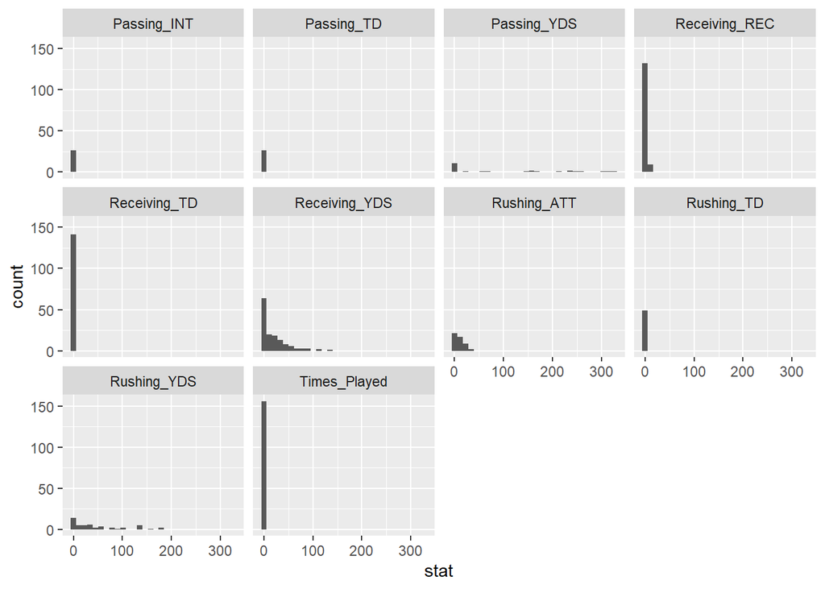

```r
x <- ggplot(data = offClean2, aes(x=stat))+geom_histogram()+facet_wrap(.~Stat_Type)
x
```

# Question 4

Answer: It looks like there was more offense verse Oklahoma than verse Oregon. There is a large amount of recieving yards verse Oklahoma and more reception than verse Oregon. This could be because we played Oklahoma twice, but that data is still strong with two players have large amounts of receiving yards than verse Oregon.

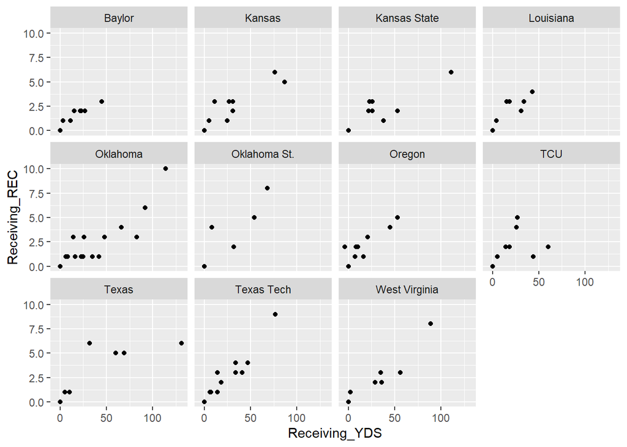

```r
ggplot(offClean, aes(x=Receiving_YDS, y=Receiving_REC))+geom_point()+facet_wrap(.~ Opponent)
```

# Question 4

Separate the Hometown column into two columns, namely, the city and the state where the player comes from. Print the first few rows of these two columns. (Hint: look at the sep= argument of separate)

```r
bioClean1 <- bioClean %>%
  separate(Hometown, c("City","State"), ", ")

str(bioClean1)
```

```
## tibble [116 x 10] (S3: tbl_df/tbl/data.frame)
##  $ Name      : Factor w/ 116 levels "Akers, Landen",..: 1 2 3 4 5 6 7 8 9 10 ...
##  $ Position  : chr [1:116] "Wide Receiver" "Tight End" "Wide Receiver" "Defensive Back" ...
##  $ feet      : num [1:116] 6 6 6 6 6 6 6 6 6 6 ...
##  $ inches    : num [1:116] 0 7 5 0 0 0 3 2 2 2 ...
##  $ Weight    : num [1:116] 191 240 208 180 195 199 253 261 288 182 ...
##  $ Class     : chr [1:116] "Redshirt Senior" "Redshirt Senior" "Redshirt Freshman" "Freshman" ...
##  $ City      : chr [1:116] "Cedar Rapids" "Nixa" "Seffner" "Ft. Lauderdale" ...
##  $ State     : chr [1:116] "Iowa" "Mo." "Fla." "Fla." ...
##  $ Highschool: chr [1:116] "Washington" "Nixa" "Armwood" "Cardinal Gibbons" ...
##  $ Height    : num [1:116] 72 79 77 72 72 72 75 74 74 74 ...
```

# Question 5

How many players are there from each state?

```r
bioClean2 <- bioClean1 %>%
  group_by(State) %>%
  summarise(Count = n())

bioClean2
```

| State | Count |
| --- | --- |
| Ariz. | 4 |
| Ark. | 1 |
| Australia | 1 |
| Calif. | 2 |
| Fla. | 14 |
| Ga. | 3 |
| Ill. | 6 |
| Iowa | 42 |
| Kan. | 4 |
| Mich | 1 |

[output cut: 11 more lines]

#Question 6

How does the performance of quarterback Brock Purdy relate to the performance of the ISU team? Comment on both the defense and offense.

**I am going to say that Brock Purdy’s performance is based on how many yards that he throws. And than success for offense would be total yards and then defense is going to be how many sacks.**

**There is a trend that as Purdy does better so does the team and especially the offense. The defense has a difficult correlation because they are not directly dependent on each other.

```r
Brock <- offClean[offClean$Name == "Purdy, Brock",]
Brock1 <- Brock %>%
  select(Passing_YDS)
Brock1
```

| Name | Opponent | Passing_YDS |
| --- | --- | --- |
| Purdy, Brock | Louisiana | 145 |
| Purdy, Brock | TCU | 211 |
| Purdy, Brock | Oklahoma | 254 |
| Purdy, Brock | Texas Tech | 302 |
| Purdy, Brock | Oklahoma St. | 162 |
| Purdy, Brock | Kansas | 239 |
| Purdy, Brock | Baylor | 164 |
| Purdy, Brock | Kansas State | 236 |
| Purdy, Brock | Texas | 312 |
| Purdy, Brock | West Virginia | 247 |

[output cut: 2 more lines]

```r
TotalYRD <- offClean2 %>%
  group_by(Opponent) %>%
  summarize(Sum = sum(stat)) %>%
  mutate()

TotalYRD
```

| Opponent | Sum |
| --- | --- |
| Baylor | 585 |
| Kansas | 930 |
| Kansas State | 924 |
| Louisiana | 514 |
| Oklahoma | 1612 |
| Oklahoma St. | 620 |
| Oregon | 635 |
| TCU | 675 |
| Texas | 813 |
| Texas Tech | 902 |

[output cut: 1 more lines]

```r
Sacks <- defClean %>%
  group_by(Opponent) %>%
  summarize(Sum = sum(Tackles_Sack))

Sacks
```

| Opponent | Sum |
| --- | --- |
| Baylor | 1.0 |
| Kansas | 4.0 |
| Kansas State | 2.0 |
| Louisiana | 1.0 |
| Oklahoma | 1.5 |
| Oklahoma St. | 0.0 |
| Oregon | 0.0 |
| TCU | 5.0 |
| Texas | 2.0 |
| Texas Tech | 1.0 |

[output cut: 1 more lines]

```r
Offense <- inner_join(TotalYRD, Sacks, by = 'Opponent')
df <- inner_join(Offense, Brock1, by = 'Opponent')

df
```

| Opponent | Sum.x | Sum.y | Name | Passing_YDS |
| --- | --- | --- | --- | --- |
| Baylor | 585 | 1.0 | Purdy, Brock | 164 |
| Kansas | 930 | 4.0 | Purdy, Brock | 239 |
| Kansas State | 924 | 2.0 | Purdy, Brock | 236 |
| Louisiana | 514 | 1.0 | Purdy, Brock | 145 |
| Oklahoma | 1612 | 1.5 | Purdy, Brock | 254 |
| Oklahoma | 1612 | 1.5 | Purdy, Brock | 322 |
| Oklahoma St. | 620 | 0.0 | Purdy, Brock | 162 |
| Oregon | 635 | 0.0 | Purdy, Brock | 156 |
| TCU | 675 | 5.0 | Purdy, Brock | 211 |
| Texas | 813 | 2.0 | Purdy, Brock | 312 |

[output cut: 2 more lines]

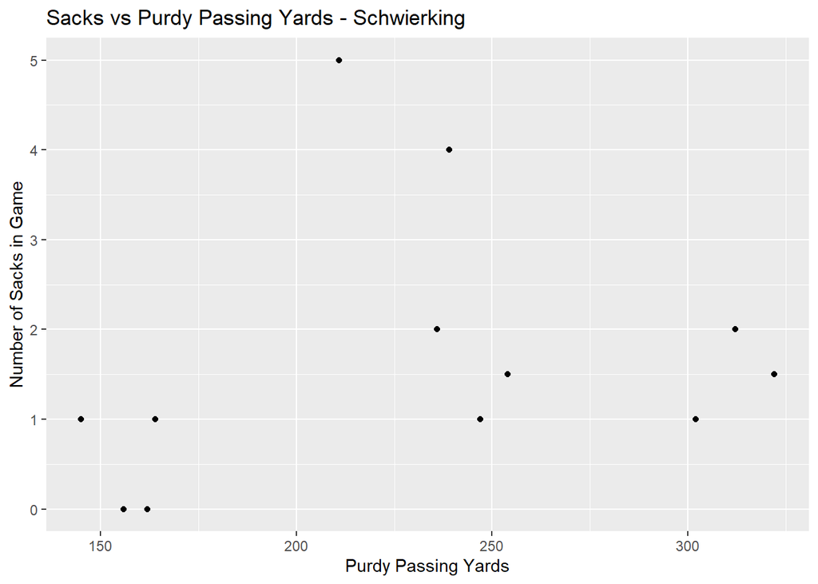

```r
ggplot(df, aes(Passing_YDS, Sum.y))+geom_point()+
  xlab("Purdy Passing Yards")+
  ylab("Number of Sacks in Game")+
  ggtitle("Sacks vs Purdy Passing Yards - Schwierking")
```

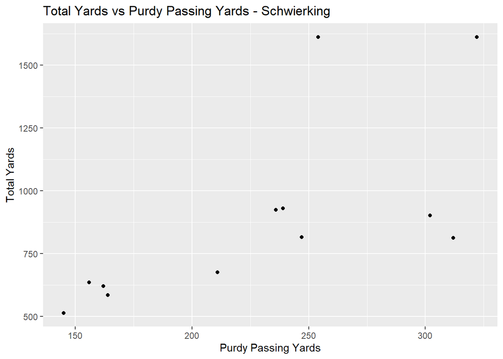

```r
ggplot(df, aes(Passing_YDS, Sum.x))+geom_point()+
  xlab("Purdy Passing Yards")+
  ylab("Total Yards")+
  ggtitle("Total Yards vs Purdy Passing Yards - Schwierking")
```